# Coursera Practical ML Project

Michael Garcia

2023-04-27

## Background

Using devices such as Jawbone Up, Nike FuelBand, and Fitbit it is now possible to collect a large amount of data about personal activity relatively inexpensively. These type of devices are part of the quantified self movement – a group of enthusiasts who take measurements about themselves regularly to improve their health, to find patterns in their behavior, or because they are tech geeks. One thing that people regularly do is quantify how much of a particular activity they do, but they rarely quantify how well they do it. In this project, your goal will be to use data from accelerometers on the belt, forearm, arm, and dumbell of 6 participants. They were asked to perform barbell lifts correctly and incorrectly in 5 different ways. More information is available from the website here: http://groupware.les.inf.puc-rio.br/har (see the section on the Weight Lifting Exercise Dataset).

## Data

The training data for this project are available here:

https://d396qusza40orc.cloudfront.net/predmachlearn/pml-training.csv

The test data are available here:

https://d396qusza40orc.cloudfront.net/predmachlearn/pml-testing.csv

The data for this project come from this source: http://groupware.les.inf.puc-rio.br/har. If you use the document you create for this class for any purpose please cite them as they have been very generous in allowing their data to be used for this kind of assignment.

Copyright 2023 Michael Garcia. GNU Affero General Public License v3.0

```r
library(lattice)
library(ggplot2)
library(caret)
library(kernlab)
library(rattle)
library(corrplot)
library(methods)
#library(torch)
#torch_tensor(1)
#library(tensorflow)
#library(keras)
set.seed(107)
```

## Classe Description

See citations for source of this description.

## Data preprocessing

```r
datasources <- setRefClass("datasources",
                       fields=list(trainurl="character",testurl="character"),
                       methods = list(
                       train_download = function()
                         {
                           trainURL <- trainurl

                           traindestURL <- file.path(getwd(),paste("train.csv",".bz2",sep = ""))

                           download.file(trainURL,destfile = traindestURL)

                           train_data <- read.csv(traindestURL)
                           return(train_data)
                         },
                       test_download = function()
                       {
                        testURL <- testurl
                        testdestURL <- file.path(getwd(),paste("test.csv",".bz2",sep = ""))
                        download.file(testURL, destfile = testdestURL)
                        test_data <- read.csv(testdestURL)
                        return(test_data)
                       }
                       )
                     )
```

```r
datasource <- datasources(
                      trainurl="https://d396qusza40orc.cloudfront.net/predmachlearn/pml-training.csv",
                      testurl="https://d396qusza40orc.cloudfront.net/predmachlearn/pml-testing.csv")
train_data <- datasource$train_download()
test_data <- datasource$test_download()
```

## Cleaning

```r
dataprep <- function(training, dataselect="train_df"){
    # create Train and Validation dataframes
    # remove values whos frequency is very low compared to the samples using Caret nearZero value
    # and remove na volumns
  training <- training[,colMeans(is.na(training)) < .9]
  training <- training[,-c(1:7)]
  nvz <- nearZeroVar(training)
  training <- training[,-nvz]
  dim(training)
  part <- createDataPartition(y=training$classe, p=0.7, list=F)
  train_df <- training[part,]
  valid_df <- training[-part,]
  sprintf("Number of training samples: %s", nrow(training))
  if (dataselect == "train_df"){
    return(train_df)
  } else if (dataselect == "valid_df"){
    return(valid_df)
  }
}

train_df <- dataprep(train_data, "train_df")
valid_df <- dataprep(train_data, "valid_df")
```

### Model Building Process

Created a class to simplify arguments for running more than one modeling technique.

For the two models that will be used, the class covers the arguments to configure how: * The cross validation will be performed (e.g. K-Fold, Simple Bootstrap, etc) * The number of resampling for tuning the performance of the cross validation * Training the models using the TRAIN and VALIDIATION data sets. * The train method inherits the control value for model tuning. * Validation of the prediction and creating the Recall, Sensitivity, Accuracy, and F1-Score model performance metrics. * Finally, running the prediction of the model using the TEST data set.

```r
### This creates a reference class that can be utilized to get the model confusion matrix, training, predictions, and performance metrics
### To simplify working with the results, the class methods create the results that are part of the object

models <- setRefClass("models",
                       fields = list(input_data="data.frame", valid_df="data.frame", test_data="data.frame",model_method="character", tunelength="numeric", model_type="character", ctrl="list", train_model_res="ANY", pred_res="ANY", confusion_matrix="ANY", test_res="ANY",plot_res="ANY"),
                       methods = list(
                         initialize = function(input_data,valid_df,test_data,model_method, tunelength, model_type) {
                           .self$input_data <- input_data
                           .self$valid_df <- valid_df
                           .self$test_data <- test_data
                           .self$model_method <- model_method
                           .self$tunelength <- tunelength
                           .self$model_type <- model_type
                           .self$ctrl <- .self$set_ctrl()
                           .self$train_model_res <- .self$train_model()
                           .self$pred_res <- .self$setPred()
                           .self$confusion_matrix <- .self$setConfusionmatrix()
                           .self$test_res <- .self$settestPred()
                           if (.self$model_type == "gbm"){
                             .self$plot_res <- .self$setPlotmodel()
                           } else if (.self$model_type != "gbm"){
                             .self$plot_res <- as.character("No Plot Available")
                             }
                           },
                         set_ctrl = function(.self)
                           {
                             ctrl <- caret::trainControl(method = .self$model_method,
                               #repeats = 3,
                               number = 3,
                               #classProbs = TRUE,
                               verboseIter = FALSE)
                             return(ctrl)
                            }
                         ,
                           train_model = function(.self)
                           {
                            res_model <- caret::train(
                                    classe~.,
                                    data = .self$input_data,
                                    method = .self$model_type,
                                    tuneLength = .self$tunelength,
                                    trControl = .self$ctrl,
                                    verbose=FALSE
                                    )
                            return(res_model)

                           },
                        setPred = function(.self){
                           res_model <- .self$train_model_res
                           pred <- stats::predict(res_model, .self$valid_df)
                           return(pred)
                          },
                        setConfusionmatrix = function(.self){
                          cmx <- caret::confusionMatrix(.self$pred_res, factor(.self$valid_df$classe))
                          return(cmx)
                        },
                        settestPred = function(){
                          pred <- predict(.self$train_model_res, .self$test_data)
                          return(pred)

                        },
                        setPlotmodel = function(){
                          ggplot(.self$train_model_res)
                        }
                         )
                     )
```

### Support Vector Machine

This method was chosen to demonstrate the speed at which the model runs. The model completed faster than gradient boosting. This is advandtagous for high dimensionality and also being memory effective. However, as seen on the results, it is not optimal for this use case. Usually used for text classification as each fold will relate to points in hyper plane for each fold based on repeated text.

#### Performance

- Accuracy is low at 0.7924
- Class A had the highest balanced accuracy at 92.06% but B through E had less than 86.9%

Create an svm model object using the models class

```r
svm_ml <- models$new(input_data = train_df, valid_df = valid_df, test_data=test_data ,model_method = "cv", tunelength=5, model_type="svmLinear")
```

```r
svm_ml$confusion_matrix
```

```
## Confusion Matrix and Statistics
##
##           Reference
## Prediction    A    B    C    D    E
##          A 1547  151   80   60   58
##          B   33  821   99   28  136
##          C   36   62  795   95   70
##          D   51   18   23  742   60
##          E    7   87   29   39  758
##
## Overall Statistics
##
##                Accuracy : 0.7924
##                  95% CI : (0.7818, 0.8027)
##     No Information Rate : 0.2845
##     P-Value [Acc > NIR] : < 2.2e-16
##
##                   Kappa : 0.736
##
##  Mcnemar's Test P-Value : < 2.2e-16
##
## Statistics by Class:
##
##                      Class: A Class: B Class: C Class: D Class: E
## Sensitivity            0.9241   0.7208   0.7749   0.7697   0.7006
## Specificity            0.9171   0.9376   0.9459   0.9691   0.9663
## Pos Pred Value         0.8159   0.7350   0.7514   0.8300   0.8239
## Neg Pred Value         0.9682   0.9333   0.9521   0.9555   0.9347
## Prevalence             0.2845   0.1935   0.1743   0.1638   0.1839
## Detection Rate         0.2629   0.1395   0.1351   0.1261   0.1288
## Detection Prevalence   0.3222   0.1898   0.1798   0.1519   0.1563
## Balanced Accuracy      0.9206   0.8292   0.8604   0.8694   0.8334
```

#### SVM Prediction Results

The prediction using the 20 observations are: C A B C A E D D A A C A B A E E A B B B

```r
svm_ml$test_res
```

```
##  [1] C A B C A E D D A A C A B A E E A B B B
## Levels: A B C D E
```

### Gradient Boosting Cross Validation

The cross validation step performs tests on several folds and produces results for the metrics measuring the overall performance. The model technique is that through each iteration, the model attempts to “correct” the loss of the previous iterations, therefore “learning” from the history of loss in its full cycle.

The gradient boosting model results in a high balanced accuracy and overall high accuracy.

#### Create the object from the models class that has the necessery outputs

```r
gbm_ml <- models$new(input_data = train_df, valid_df = valid_df, test_data=test_data ,model_method = "cv", tunelength=5, model_type="gbm")
```

#### Confusion Matrix

```r
gbm_ml$confusion_matrix
```

```
## Confusion Matrix and Statistics
##
##           Reference
## Prediction    A    B    C    D    E
##          A 1671    3    0    0    0
##          B    2 1134    2    0    2
##          C    0    2 1023    3    0
##          D    0    0    1  961    3
##          E    1    0    0    0 1077
##
## Overall Statistics
##
##                Accuracy : 0.9968
##                  95% CI : (0.995, 0.9981)
##     No Information Rate : 0.2845
##     P-Value [Acc > NIR] : < 2.2e-16
##
##                   Kappa : 0.9959
##
##  Mcnemar's Test P-Value : NA
##
## Statistics by Class:
##
##                      Class: A Class: B Class: C Class: D Class: E
## Sensitivity            0.9982   0.9956   0.9971   0.9969   0.9954
## Specificity            0.9993   0.9987   0.9990   0.9992   0.9998
## Pos Pred Value         0.9982   0.9947   0.9951   0.9959   0.9991
## Neg Pred Value         0.9993   0.9989   0.9994   0.9994   0.9990
## Prevalence             0.2845   0.1935   0.1743   0.1638   0.1839
## Detection Rate         0.2839   0.1927   0.1738   0.1633   0.1830
## Detection Prevalence   0.2845   0.1937   0.1747   0.1640   0.1832
## Balanced Accuracy      0.9987   0.9972   0.9980   0.9980   0.9976
```

#### View Plot Results

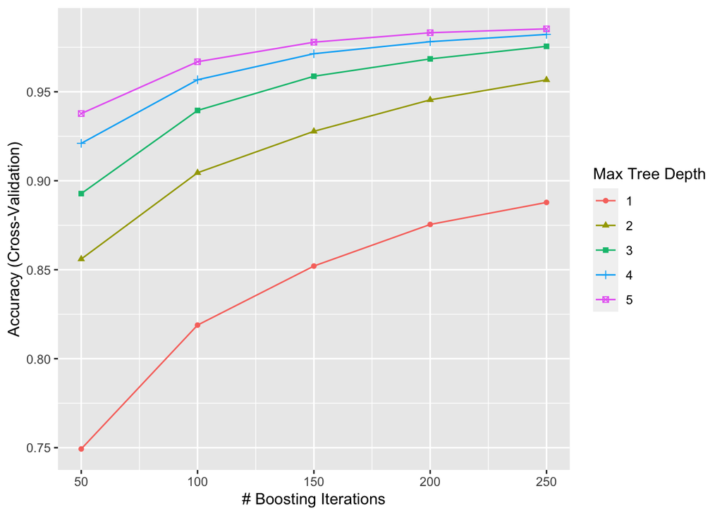

```r
gbm_ml$plot_res
```

#### Gradient Boost Test Predictions

We can see here the predictions using the test dataset

```r
gbm_ml$test_res
```

```
##  [1] B A B A A E D B A A B C B A E E A B B B
## Levels: A B C D E
```

### Conclusion:

The Gradient Boosting Model had the highest scores, and higher upper and lower confidence intervals at 95 %. SVM does complete its run given the same arguments for cross validation and sampling.

### Notes:

ML Library used is Caret: https://cran.r-project.org/web/packages/caret/vignettes/caret.html

### Citation:

Velloso, E.; Bulling, A.; Gellersen, H.; Ugulino, W.; Fuks, H. Qualitative Activity Recognition of Weight Lifting Exercises. Proceedings of 4th International Conference in Cooperation with SIGCHI (Augmented Human ’13) . Stuttgart, Germany: ACM SIGCHI, 2013.

Read more: http:/groupware.les.inf.puc-rio.br/har#wle_paper_section#ixzz4TjplRc5n